# Experiment Analysis

## Load Data

We first load the raw PCIbex results file. Because PCIbex result files can have variable column counts and comment lines, we read it carefully.

```r
# Define the file path
file_path <- "results_prod-6.csv"

# Read the file. We will read it as a raw text first to handle the variable rows.
# However, standard read.csv with fill=TRUE and strict column naming often works if the header structure is known.
# Given the complex nature, let's read the lines and parse relevant ones.

raw_lines <- readLines(file_path)
# Filter out comment lines that don't start with digits (data lines start with timestamp)
data_lines <- raw_lines[!grepl("^#", raw_lines)]

# Create a temporary connection
con <- textConnection(data_lines)
data <- read.csv(
    con,
    header = FALSE,
    fill = TRUE,
    col.names = paste0("V", 1:30),
    stringsAsFactors = FALSE
)
close(con)

# View basics
# head(data)
```

## Demographics

```r
# Filter for demographics
# V6 is Label ("demografik")
# V9 is Element Name ("Age", "Gender", etc.)
# V10 is Parameter ("Final", "First", etc.)
# V11 is Value
demographics_raw <- data %>%
    filter(V6 == "demografik") %>%
    filter(
        V9 %in%
            c(
                "Age",
                "Gender",
                "NativeLanguage",
                "ForeignLanguage",
                "School",
                "DominantLanguage"
            )
    ) %>%
    # We prefer the "Final" value if multiple exist
    filter(V10 == "Final") %>%
    select(MD5 = V2, Parameter = V9, Value = V11) %>%
    distinct()

# Pivot to wide format for a clean table
demographics_table <- demographics_raw %>%
    group_by(MD5, Parameter) %>%
    summarise(Value = last(Value), .groups = 'drop') %>%
    pivot_wider(names_from = Parameter, values_from = Value)

# Check if table is empty
if (nrow(demographics_table) == 0) {
    print("No demographic data found matching criteria.")
} else {
    # Display
    print(
        kable(demographics_table, caption = "Participant Demographics") %>%
            kable_styling(bootstrap_options = c("striped", "hover"))
    )
}
```

[output not shown]

[output cut: 96 more lines]

[output not shown]

```r
# Summary of Age if numeric
demographics_table <- demographics_table %>%
    mutate(Age = as.numeric(as.character(Age)))
age_summary <- demographics_table %>%
    summarise(
        Mean_Age = mean(Age, na.rm = TRUE),
        Min_Age = min(Age, na.rm = TRUE),
        Max_Age = max(Age, na.rm = TRUE),
        N = n()
    )

kable(age_summary, caption = "Age Summary")
```

Age Summary

| Mean_Age | Min_Age | Max_Age | N |
| --- | --- | --- | --- |
| 28.21429 | 20 | 58 | 15 |

## Data Cleaning

Now we extract the trial data. We look for the main experimental and filler trials. Based on the log file structure, the relevant columns for analysis (Condition, Response, RT) start from Column 13.

We will filter for rows that represent the *end* of a trial or contain the logged variables. Typically in PCIbex with `log`, every line for that trial has the logged variables. We just need to pick one line per trial to avoid duplication. The `_Trial_` `End` event or `time limit` `End` event might be duplicated. A safe bet is using the unique `Order` (V4) and `Item_set` (V14) per participant, but simpler is to pick a distinct row type.

Let’s inspect the `Item_Type` (V16).

```r
# Select relevant columns for experimental data
# Columns 1-12 are standard. 13+ are user defined.
# V13: Part_ID
# V14: Item_set
# V15: Order (Logged User Variable) - NOTE: V4 is also order number of item.
# V16: Item_Type
# V17: Condition1
# V18: Condition2
# V19: Correct_Resp
# V20: Response
# V21: RT
# V22: Group?
# V23: Sentence
# V24: Comments?

main_data <- data %>%
    filter(V16 %in% c("experimental", "filler")) %>%
    select(
        Part_ID = V13,
        Item_Set = V14,
        Trial_Order = V15,
        Item_Type = V16,
        Condition1 = V17,
        Condition2 = V18,
        Correct_Resp = V19,
        Participant_Response = V20,
        RT = V21,
        Sentence = V23
    ) %>%
    # Filter only unique rows per trial.
    # Since multiple lines (Start, End, Key press) all have the logs attached, we get duplicates.
    distinct(Part_ID, Item_Set, Trial_Order, .keep_all = TRUE) %>%
    mutate(
        RT = as.numeric(as.character(RT)),
        # Convert Response to Binary Accuracy/Acceptance
        # Assuming "Yes" is the target for acceptance or correctness
        Response_Binary = ifelse(Participant_Response == "Yes", 1, 0),
        Is_Correct = ifelse(Participant_Response == Correct_Resp, 1, 0)
    )

# Check data integrity (e.g. valid RTs)
# Clean outliers or missed responses (No_Response)
clean_data <- main_data %>%
    filter(Participant_Response %in% c("Yes", "No")) %>%
    filter(!is.na(RT))

head(clean_data)
```

```
          Part_ID Item_Set Trial_Order    Item_Type Condition1     Condition2
1 x7r0WCXblZ1Q1Bg       37           2       filler         SG             SG
2 x7r0WCXblZ1Q1Bg       27           3       filler         PL             PL
3 x7r0WCXblZ1Q1Bg        1           4 experimental        gen attractorMatch
4 x7r0WCXblZ1Q1Bg       32           5       filler         PL             PL
5 x7r0WCXblZ1Q1Bg       30           6       filler         PL             PL
6 x7r0WCXblZ1Q1Bg       71           7       filler         PL             SG
  Correct_Resp Participant_Response   RT
1          Yes                  Yes  579
2          Yes                  Yes 2894
3           No                   No 1061
4          Yes                  Yes  496
5          Yes                  Yes  435
6           No                   No  447
                                                             Sentence
1 Menajer dizi setindeki bitmeyen kavgalardan bunalmıştır muhtemelen.
2 Avrupalılar Hindistan'ı ararken yanlışlıkla Amerika'yı keşfettiler.
3    Göçmenlerin sözcüsü geçen hafta protestoda aralıksız bağırdılar.
4                Şairler seyirci tarafından beğenilmeyince üzüldüler.
5        Teknisyenler hızlı çalıştıklarından işe tekrar çağırıldılar.
6            Yetkililer kantindeki kahveye bir  zam daha getirilmedi.
  Response_Binary Is_Correct
1               1          1
2               1          1
3               0          1
4               1          1
5               1          1
6               0          1
```

## Descriptive Statistics

### Fillers

We calculate the accuracy for fillers to check participant quality.

```r
filler_stats <- clean_data %>%
    filter(Item_Type == "filler") %>%
    group_by(Condition1, Condition2) %>% # Group by filler types if needed
    summarise(
        Mean_Accuracy = mean(Is_Correct, na.rm = TRUE),
        SE_Accuracy = sd(Is_Correct, na.rm = TRUE) / sqrt(n()),
        Mean_RT = mean(RT, na.rm = TRUE),
        count = n(),
        .groups = 'drop'
    )

kable(filler_stats, caption = "Descriptive Stats for Fillers") %>%
    kable_styling()
```

Descriptive Stats for Fillers

| Condition1 | Condition2 | Mean_Accuracy | SE_Accuracy | Mean_RT | count |
| --- | --- | --- | --- | --- | --- |
| PL | PL | 0.9633508 | 0.0136316 | 887.9058 | 191 |
| PL | SG | 0.8912467 | 0.0160556 | 910.1538 | 377 |
| SG | SG | 0.8869258 | 0.0133230 | 957.3481 | 566 |

### Experimental Items

We calculate the “Acceptance Rate” (proportion of ‘Yes’) for experimental conditions.

```r
exp_stats <- clean_data %>%
    filter(Item_Type == "experimental") %>%
    group_by(Condition1, Condition2) %>%
    summarise(
        Mean_Acceptance = mean(Response_Binary, na.rm = TRUE),
        SE_Acceptance = sd(Response_Binary, na.rm = TRUE) / sqrt(n()),
        Mean_RT = mean(RT, na.rm = TRUE),
        SE_RT = sd(RT, na.rm = TRUE) / sqrt(n()),
        count = n(),
        .groups = 'drop'
    )

kable(exp_stats, caption = "Descriptive Stats for Experimental Conditions") %>%
    kable_styling()
```

Descriptive Stats for Experimental Conditions

| Condition1 | Condition2 | Mean_Acceptance | SE_Acceptance | Mean_RT | SE_RT | count |
| --- | --- | --- | --- | --- | --- | --- |
| gen | attractorMatch | 0.2816901 | 0.0537641 | 1096.0423 | 71.36196 | 71 |
| gen | noMatch | 0.1944444 | 0.0469695 | 859.2778 | 47.53271 | 72 |
| gen | targetMatch | 0.6944444 | 0.0546682 | 1184.5694 | 76.70831 | 72 |
| nom | attractorMatch | 0.1250000 | 0.0392491 | 961.4583 | 58.18534 | 72 |
| nom | noMatch | 0.1285714 | 0.0402962 | 1035.0000 | 70.10142 | 70 |
| nom | targetMatch | 0.8450704 | 0.0432479 | 965.2394 | 55.52700 | 71 |

## Visualization

### Mean and SE Plot (Acceptance)

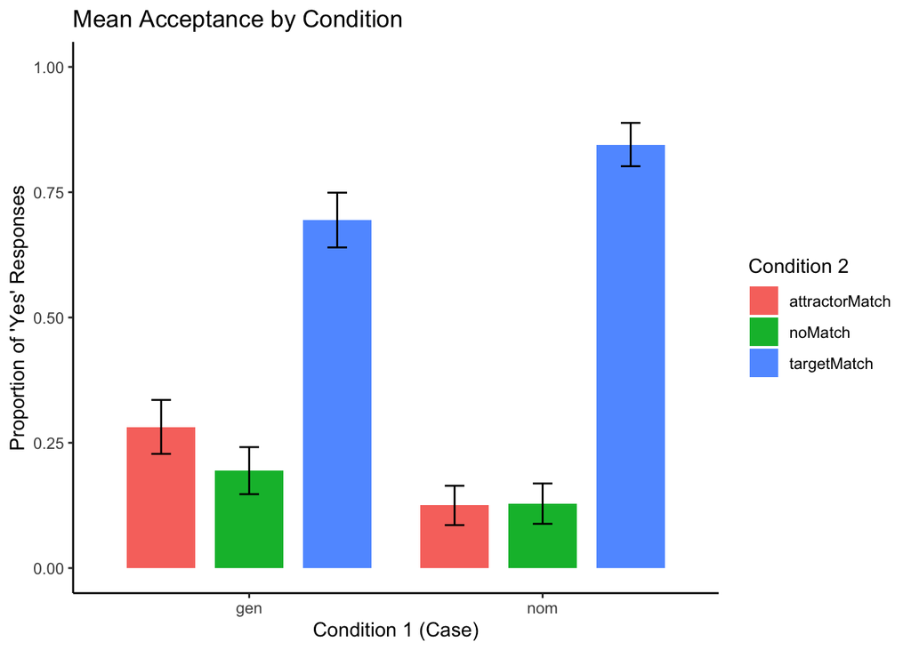

```r
# Create a combined Label for plotting if needed, or use facets
ggplot(exp_stats, aes(x = Condition1, y = Mean_Acceptance, fill = Condition2)) +
    geom_bar(stat = "identity", position = position_dodge(0.9), width = 0.7) +
    geom_errorbar(
        aes(
            ymin = Mean_Acceptance - SE_Acceptance,
            ymax = Mean_Acceptance + SE_Acceptance
        ),
        width = 0.2,
        position = position_dodge(0.9)
    ) +
    labs(
        title = "Mean Acceptance by Condition",
        x = "Condition 1 (Case)",
        y = "Proportion of 'Yes' Responses",
        fill = "Condition 2"
    ) +
    theme_classic() +
    ylim(0, 1)
```

```r
ggsave("plot_mean_acceptance.png", width = 8, height = 6)
```

### Box Plot (Reaction Times)

We visualize the specific distribution of Reaction Times (or we could visualize the by-participant means of acceptance if preferred, but RTs are continuous and good for boxplots). If you prefer a boxplot of the binary data (which shows medians), it might be less informative, so I will plot the RTs. If you specifically meant “Box plot for Acceptance rates” (aggregating by participant), I can do that too. Let’s do RTs for now as it’s standard for boxplots.

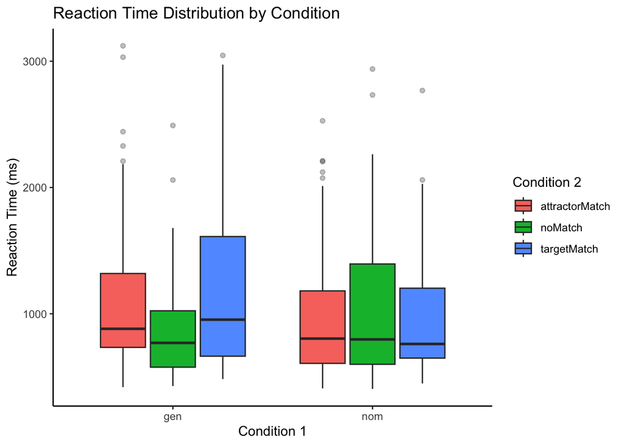

```r
clean_data %>%
    filter(Item_Type == "experimental") %>%
    ggplot(aes(x = Condition1, y = RT, fill = Condition2)) +
    geom_boxplot(outlier.alpha = 0.3) +
    labs(
        title = "Reaction Time Distribution by Condition",
        x = "Condition 1",
        y = "Reaction Time (ms)",
        fill = "Condition 2"
    ) +
    theme_classic()
```

### Box Plot (Acceptance by Participant)

Visualizing the spread of acceptance rates across participants.

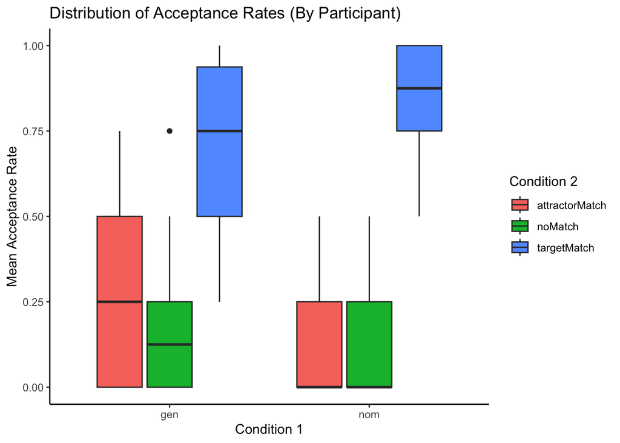

```r
participant_means <- clean_data %>%
    filter(Item_Type == "experimental") %>%
    group_by(Part_ID, Condition1, Condition2) %>%
    summarise(Mean_Acc = mean(Response_Binary), .groups = 'drop')

ggplot(
    participant_means,
    aes(x = Condition1, y = Mean_Acc, fill = Condition2)
) +
    geom_boxplot() +
    labs(
        title = "Distribution of Acceptance Rates (By Participant)",
        x = "Condition 1",
        y = "Mean Acceptance Rate",
        fill = "Condition 2"
    ) +
    theme_classic()
```